# TUGAS DISKUSI PENGENALAN STATISTIKA SESI 2

- NAMA : RIZIQ LILI ULIL ALBAB
- NIM : 058487469

## SOAL

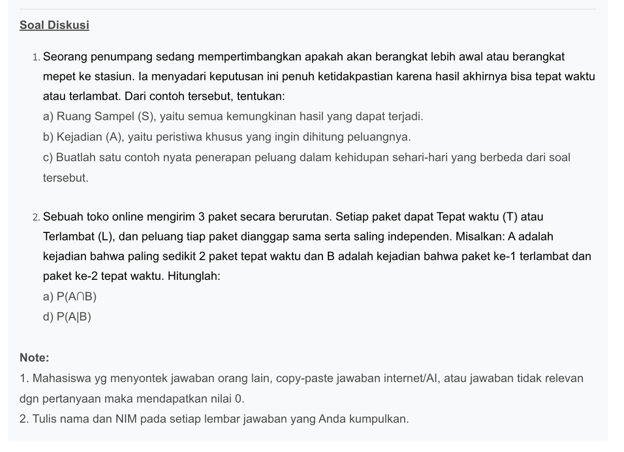

### NOTE : SEMUA NOTASI MATEMATIKA YANG SAYA TULIS MENGGUNAKAN SYNTAX LATEX

### JAWABAN 1

### 1. Penumpang ke stasiun

- a Ruang sample Kemungkinan hasil yang dapat terjadi adalah:

  S = {tepat waktu, terlambat}
- b Kejadian (A)

  Misalnya kejadian yang ingin dihitung peluangnya adalah penumpang tepat waktu.

  A = {tepat waktu}
- c Saat seseorang membeli makanan lewat aplikasi ojek online, ada ketidakpastian apakah makanan akan sampai cepat atau terlambat.

  Ruang sampelnya:

  S = {cepat, terlambat}

  Misalnya kejadian A adalah makanan sampai cepat, maka:

  A = {cepat}

  Peluang digunakan untuk memperkirakan apakah kita perlu memesan lebih awal atau bisa menunggu waktu makan.

## 2. Pengiriman 3 Paket

Setiap paket dapat **Tepat waktu (T)** atau **Terlambat (L)**.

Ruang sampel:

$$ S = \{TTT, TTL, TLT, TLL, LTT, LTL, LLT, LLL\} $$

Karena semua kemungkinan memiliki peluang yang sama, maka peluang setiap hasil adalah:

$$ P = \frac{1}{8} $$

Kejadian **A** adalah paling sedikit 2 paket tepat waktu.

$$ A = \{TTT, TTL, TLT, LTT\} $$

Kejadian **B** adalah paket ke-1 terlambat dan paket ke-2 tepat waktu.

$$ B = \{LTT, LTL\} $$

### a) Menghitung $P(A \cap B)$

Irisan antara kejadian **A** dan **B** adalah:

$$ A \cap B = \{LTT\} $$

Maka:

$$ P(A \cap B) = \frac{1}{8} $$

### d) Menghitung $P(A \mid B)$

Rumus peluang bersyarat:

$$ P(A \mid B) = \frac{P(A \cap B)}{P(B)} $$

Diketahui:

$$ P(A \cap B) = \frac{1}{8} $$

$$ P(B) = \frac{2}{8} $$

Maka:

$$ P(A \mid B) = \frac{\frac{1}{8}}{\frac{2}{8}} $$

$$ P(A \mid B) = \frac{1}{2} $$

Jadi, hasil akhirnya adalah:

$$ P(A \cap B) = \frac{1}{8} $$

$$ P(A \mid B) = \frac{1}{2} $$

Referensi:

- Dr. Sutikno, M.Si., dan Dr. Dewi Juliah Ratnaningsih, S.Si., M.Si., Metode Statistika I (BMP SATS4121)

Tool:

- ChatGPT: Digunakan sebagai alat bantu untuk menyusun sintaks LaTeX dari notasi yang ditulis secara manual.

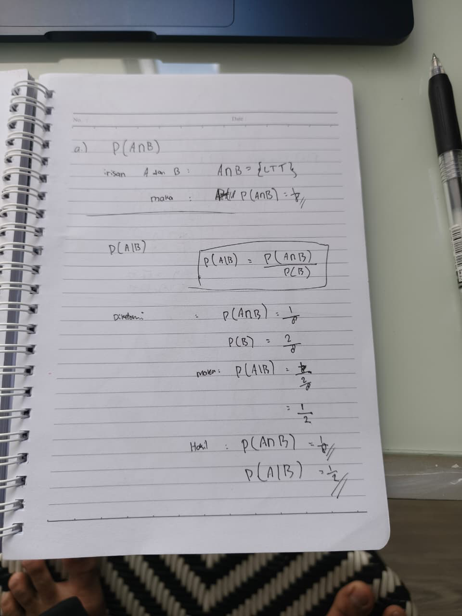